# Predicting Fast Growing Firms

Fatima Arshad

2/25/2022

## Introduction

Investment managers need to allocate funds to opportunities where the return can be maximized. The goal of this report is to classify companies into fast growing companies and companies not having a fast sales growth. This classification will eventually help the investment managers in well-informed decision making as to which companies to invest for maximum return.This report will discuss three models that predict probabilities of companies that would have a Compound Annual Growth Rate (CAGR) in sales of 40% or more between 2012 and 2014 and then classify the companies into two classes. This means that companies having a Compound Annual Growth Rate of 40% or more will be classified as a fast growing company. Input to these models are several features like income statement, balance sheet items which are necessary for an accurate prediction. The analysis will be done using the Logit, Logit LASSO, and Random Forest models with 5-fold cross validation. The accuracy and model selection of this analysis will be base upon the values of root mean squared error, the area under the curve, and the average expected loss.

## Data Selection

The data used in this report is prepared by Bisnode and it has been sourced from the [OSF](https://osf.io/3qyut/) website. The dataset is large containing observations of more than 287,000 rows with 48 explanatory variables in total. The time frame of the observations was from 2005 till 2016. We will build a model for classification of fast growing companies and thus set the cut-off sales at 40% 2 years CAGR. 6 years of panel data of these companies is filtered i.e. from 2010 to 2015 as part of the data preparation process. Moreover, 2-years CAGR is calculated using data from 2012 till 2014 to ascertain stable growth in sales since they are prone to yearly fluctuation.

Next, dummy variable is created for identification and selection of firms which are alive, which is evident in the number of sales being greater than zero and not null. This analysis is only focused on small and medium sized companies. The size of the company is determined by the number of sales in between the range of 1000 to 10 million euros. Finally, for prediction, the year 2012 data was used with observations that had a CAGR of less than 3000.

## Data Engineering

As part of the exploratory data analysis, the distribution of sales is visualized. It can be seen that it is highly skewed which is why we create a new variable with log of sales to achieve a near-normal distribution. Secondly, we calculate the age of the firm by subtracting the founding year from the current year of the observation. Thirdly, for financial columns, we create new columns that contain normalized values for both balance sheet and income statement to make a fair comparison across different sized companies. Next, we normalize the balance sheet items by dividing the items from total assets. We also calculate the total assets by combining intangible assets, current assets, and fixed assets. Similarly, income statement items is normalized by dividing them from total sales. All negative values across across financial variables like intangible assets, current assets, and fixed assets are identified by flag variables and are replaced with 0. These flag variables are tested for variations in observations and the ones with no variations were dropped. Similarly, CEO age is also calculated by subtracting birth-year from the current year of the observations and flags are created to identify CEO age, with less than 25 being classified as low, greater than 75 as high, and missing for where the CEO age was coming out as NA.

Missing values in labor average column are replaced by the mean value in a new column. A flag variable was then created to identify the missing values. A new level variable was then created to classify fast growth companies and others where the value of 1 was assigned to fast-growth companies. After making all these modifications, we are then left with 10558 observations with 115 variables in total. Finally, to make it easier to use our variables in the prediction models, we stored specific variables into different groups based on our domain knowledge and data engineering to create models with different level of complexity.

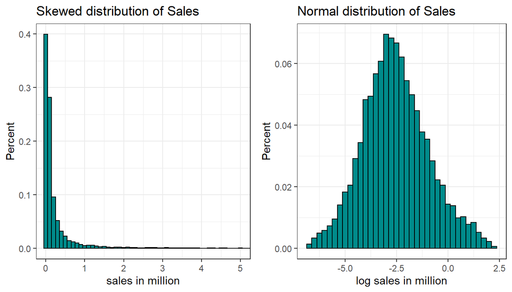